# Lecture_02.ggplot2.p1.JupyterHub.live

## Advanced Graphics and Data Visualization in R

## Lecture 02: `ggplot2` and choosing the right visualization for your audience

## 0.1.0 An overview of Advanced Graphics and Data Visualization in R

**"Advanced Graphics and Data Visualization in R"** is brought to you by the Centre for the Analysis of Genome Evolution & Function's (CAGEF) bioinformatics training initiative. This CSB1021 was developed to enhance the skills of students with basic backgrounds in R by focusing on available philosophies, methods, and packages for plotting scientific data. While the datasets and examples used in this course will be centred on SARS-CoV2 epidemiological and genomic data, the lessons learned herein will be broadly applicable.

This lesson is the second in a 6-part series. The aim for the end of this series is for students to recognize how to import, format, and display data based on their intended message and audience. The format and style of these visualizations will help to identify and convey the key message(s) from their experimental data.

The structure of the class is a **code-along style** in Jupyter notebooks. At the start of each lecture, skeleton versions of the lecture will be provided for use on the [University of Toronto Jupyter Hub](https://jupyter.utoronto.ca/hub/login) so students can program along with the instructor.

## 0.2.0 Lecture objectives

This week will delve into some helpful visualization available through the `ggplot2` package. First we'll go over deciding which visualizations are best for what we want to accomplish and then explore some of these in more detail.

At the end of this lecture you will have covered the following topics

1. The grammar of graphics
2. Scatterplots and their variants
3. Barplots and their variants
4. Density plots and their variants
5. Boxplots and their variants

## 0.3.0 A legend for text format in Jupyter markdown

`grey background` - a package, function, code, command or directory. Backticks are also use for in-line code.  
*italics* - an important term or concept or an individual file or folder  
**bold** - heading or a term that is being defined  
blue text - named or unnamed hyperlink

## 0.4.0 Data used in this lesson

Today's datasets will focus on some more Ontario public health unit data. We'll deep dive a bit more into the demographics of SARS-CoV-2 infection, hospitalization, and survival.

## 0.4.1 Dataset 2: PHU_population_information.csv

Retrieved from the open data sets available at [Public Health Ontario](https://www.publichealthontario.ca/en/data-and-analysis/using-data/open-data), this data provides summary statistic information for all PHUs in Ontario including the population size for each PHU.

## 0.4.2 Dataset 1: Ontario_daily_change_in_cases_by_phu_long.csv

This data originated from the Ontario Provincial government but was tidied during lecture 01 to reflect a long-format set of data compatible with our needs.

## 0.4.3 Dataset 3: Ontario_age_sex_COVID-19.csv

Retrieved from the open data sets available at [Public Health Ontario](https://www.publichealthontario.ca/en/data-and-analysis/using-data/open-data), this dataset focuses on summarizing PHU data across age and sex groups.

## 0.5.0 Packages used in this lesson

`repr`- a package useful for altering some of the attributes of objects related to the R kernel.

`tidyverse` which has a number of packages including `dplyr`, `tidyr`, `stringr`, `forcats` and `ggplot2`

`viridis` helps to create color-blind palettes for our data visualizations

`lubridate` and `zoo` are helper packages used for working with date formats in R

`ggridges` and `GGally` which are new packages we need to install. They'll help us generate some nice graphs.

```r
#install.packages("ggridges")
#install.packages("GGally")
```

```r
# Packages to help tidy our data
library(tidyverse)

# Packages for the graphical analysis section
library(repr)
library(viridis)

# New visualisation packages
library(ggridges) # ridgeline plots
library(GGally) # Parallel coordinate plots

# packages used for working with/formating dates in R
library(lubridate)
library(zoo)
```

## 1.0.0 Why is data visualization important?

How do we extract meaningful insights from our data? If you have previously explored Anscombe's quartet (ref) you'll know that, as scientists and lay people, we can sometime be obsessed with summary statistics - mean, median, mode, standard deviation. While these values are a helpful way to quickly assess a population, they can be flawed to the point of deception. Instead, we should temper our investigations by visualizing our data. A deeper understanding of your data trends and potential models comes from dissecting attributes of your data which can jump out more easily through visualization.

Equally important is the ability to convey our findings to others. The right visualizations, whether simplistic or complex should, should effectively communicate our key message.

## 1.1.0 The grammar of graphics

One approach to effective data visualization relies on the Grammar of Graphics framework originally proposed by Lelan Wilkinson (ref).The idea of grammar can be summarized as follows:

- Grammar is the foundational set of rules that define the components of a language.
- A language is built on a structure that consists of syntax and semantics.

The grammar of graphics facilitates the concise description of any components of any graphics. Hadly Wickham of `tidyverse` fame has proposed a variant on this concept - the layered grammar of graphics framework. By following a layered approach of defined components, it can be easy to build a visualization.

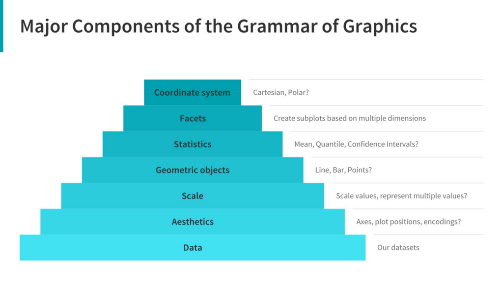

The Major Components of the Grammar of Graphics by [Dipanjan Sarkar](https://towardsdatascience.com/a-comprehensive-guide-to-the-grammar-of-graphics-for-effective-visualization-of-multi-dimensional-1f92b4ed4149)

We can break down the above pyramid by the base components, building from the bottom upwards.

1. Data: your visualization always starts here. What are the dimensions you want to visualize. What aspect of your data are you trying to convey?
1. Aesthetics: assign your axes based on the data dimensions you have chosen. Where will the majority of the data fall on your plot? Are there other dimensions (such as categorically encoded groupings) that can be conveyed by aspects like size, shape, colour, fill, etc.
1. Scale: do you need to scale/transform any values to fit your data within a range?
1. Geometric objects: how will you display your data within your visualization. Which `geom_*` will you use?
1. Statistics: are there additional summary statistics that should be included in the visualization? Some examples include central tendency, spread, confidence intervals, standard error, etc.
1. Facets: will generating subplot of the data add a dimension to our visualization that would otherwise by lost?
1. Coordinate system: will your visualization follow a classis cartesian, semi-log, polar, etc. coordinate system?

## 1.2.0 Cumulative caseload data by PHU

Let's look at a summarized data set this week with cumulative case counts across all PHUs in Ontario. What is nice about this data set is that it also carries some population data with it to give us a sense of proportions. Steps we'll take in working with this data:

1. Open up the data with `read_csv()`
2. Fix the column names
3. Drop the "recent" data but keep the cumulative data

Let's open that up with our friend `read_csv()`

```r
phu_information.df <- read_csv("./data/PHU_population_information.csv")
str(phu_information.df)
head(phu_information.df)
```

```
tibble [35 x 10] (S3: spec_tbl_df/tbl_df/tbl/data.frame)
 $ Geographic area                  : chr [1:35] "Ontario" "Algoma Public Health" "Brant County Health Unit" "Durham Region Health Department" ...
 $ Recent Case Count                : num [1:35] 17841 13 187 604 19 ...
 $ Recent Case Rate                 : num [1:35] 120 11.4 120.5 84.8 11.2 ...
 $ Cumulative Case Count            : num [1:35] 325254 219 2045 12693 716 ...
 $ Cumulative Case Rate             : num [1:35] 2188 191 1318 1782 422 ...
 $ Cumulative Hospitalizations Count: num [1:35] 16183 6 59 611 25 ...
 $ Cumulative Hospitalizations Rate : num [1:35] 108.9 5.2 38 85.8 14.7 ...
 $ Cumulative Deaths Count          : num [1:35] 7212 4 14 303 2 ...
 $ Cumulative Deaths Rate           : num [1:35] 48.5 3.5 9 42.5 1.2 39.4 29.6 31.8 50.5 3.6 ...
 $ Population                       : num [1:35] 14864428 114434 155203 712402 169884 ...
 - attr(*, "spec")=
  .. cols(
  ..   `Geographic area` = col_character(),
  ..   `Recent Case Count` = col_number(),
  ..   `Recent Case Rate` = col_double(),
  ..   `Cumulative Case Count` = col_number(),
  ..   `Cumulative Case Rate` = col_number(),
  ..   `Cumulative Hospitalizations Count` = col_number(),
  ..   `Cumulative Hospitalizations Rate` = col_double(),
  ..   `Cumulative Deaths Count` = col_number(),
  ..   `Cumulative Deaths Rate` = col_double(),
  ..   Population = col_number()
  .. )
```

A tibble: 6 × 10

| Geographic area <chr> | Recent Case Count <dbl> | Recent Case Rate <dbl> | Cumulative Case Count <dbl> | Cumulative Case Rate <dbl> | Cumulative Hospitalizations Count <dbl> | Cumulative Hospitalizations Rate <dbl> | Cumulative Deaths Count <dbl> | Cumulative Deaths Rate <dbl> | Population <dbl> |
| --- | --- | --- | --- | --- | --- | --- | --- | --- | --- |
| Ontario | 17841 | 120.0 | 325254 | 2188.1 | 16183 | 108.9 | 7212 | 48.5 | 14864428 |
| Algoma Public Health | 13 | 11.4 | 219 | 191.4 | 6 | 5.2 | 4 | 3.5 | 114434 |
| Brant County Health Unit | 187 | 120.5 | 2045 | 1317.6 | 59 | 38.0 | 14 | 9.0 | 155203 |
| Durham Region Health Department | 604 | 84.8 | 12693 | 1781.7 | 611 | 85.8 | 303 | 42.5 | 712402 |
| Grey Bruce Health Unit | 19 | 11.2 | 716 | 421.5 | 25 | 14.7 | 2 | 1.2 | 169884 |
| Haldimand-Norfolk Health Unit | 79 | 69.2 | 1491 | 1307.0 | 63 | 55.2 | 45 | 39.4 | 114081 |

```r
# Take our PHU information and tidy it up a bit

phu_information.df %<>%
rename_with(str_to_lower) %>%
rename_with(str_replace_all, pattern="\\s", replacement="_") %>%
mutate(geographic_area = str_replace_all(.$geographic_area,
                                         pattern=c("(^Public\\sHealth\\s)"),
                                         replacement = "")) %>%
mutate(geographic_area = str_replace_all(.$geographic_area,
                                         pattern=c("(\\sPublic[\\s\\w]*)|(\\sHealth[\\s\\w]*)"),
                                         replacement = "")) %>%
select(-2, -3) %>%
rename_with(str_replace_all, pattern="cumulative_", replacement = "") %>%
rename(public_health_unit = geographic_area)

head(phu_information.df)
```

A tibble: 6 × 8

| public_health_unit <chr> | case_count <dbl> | case_rate <dbl> | hospitalizations_count <dbl> | hospitalizations_rate <dbl> | deaths_count <dbl> | deaths_rate <dbl> | population <dbl> |
| --- | --- | --- | --- | --- | --- | --- | --- |
| Ontario | 325254 | 2188.1 | 16183 | 108.9 | 7212 | 48.5 | 14864428 |
| Algoma | 219 | 191.4 | 6 | 5.2 | 4 | 3.5 | 114434 |
| Brant County | 2045 | 1317.6 | 59 | 38.0 | 14 | 9.0 | 155203 |
| Durham Region | 12693 | 1781.7 | 611 | 85.8 | 303 | 42.5 | 712402 |
| Grey Bruce | 716 | 421.5 | 25 | 14.7 | 2 | 1.2 | 169884 |
| Haldimand-Norfolk | 1491 | 1307.0 | 63 | 55.2 | 45 | 39.4 | 114081 |

## 1.3.0 Which aspects of the data do we wish to highlight?

Let's take a look at the [following chart](https://extremepresentation.typepad.com/blog/2006/09/choosing_a_good.html) from from Dr. Andrew V. Abela.

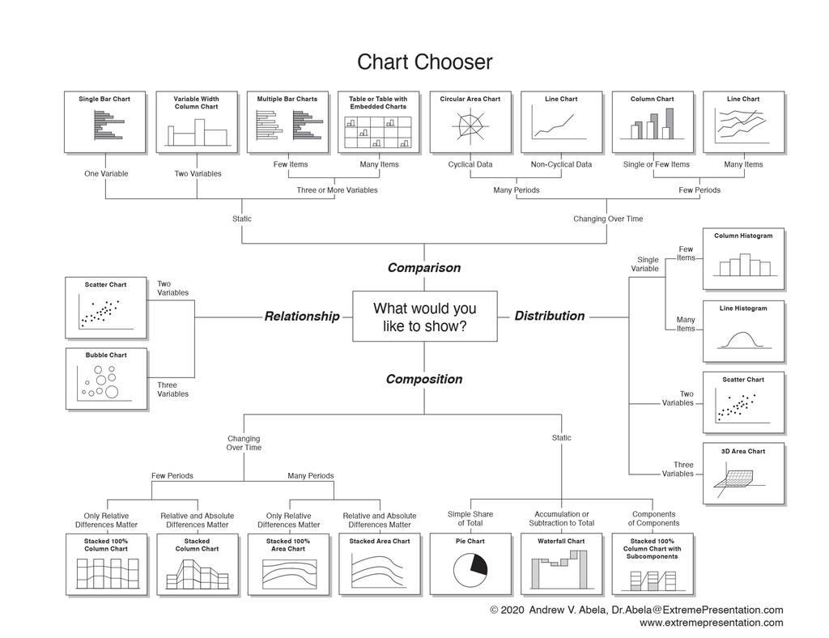

From the flowchart above we'll explore mainly looking at relationships, composition using our dataset as a basis for our visualizations. We'll cover distributions and comparison with a more complex dataset later in this lecture.

## 2.0.0 Visualizations help us identify relationships and correlations

Depending on the nature of your data and its dimensions there are a number of plots to choose from to represent and convey relationships between your variables. These various plots can reveal trends, correlations, and ultimately relationships between variables. As an initial form of graphical assessment, scatterplots build a framework for exploring our data further.

| Relationship Description | Types of charts |
| --- | --- |
| Finding correlations in your data | Scatterplot |
|  | Bubble hart |
|  | Heatmap |
| Showing connections between groups | Arc diagram |
|  | Chord diagram |
|  | Connection map |
|  | Network diagram |
|  | Non-ribbon chord diagram |
|  | Tree diagram |
| Show relationships and connections between the data | Heatmap |
| or showing correlations between two or more variables | Marimekko Chart |
|  | Parallel coordinates plot |
|  | Radar chart |
|  | Venn diagram |

Today we'll focus on the scatterplot and it's variant the bubblechart. Parallel coordinate plots will also make an appearance later on during this lecture.

## 2.1.0 Scatterplots and bubblecharts are both `geom_point()` graphs

When we try to examine relationships, one direction we can take is to look for trends by comparing one variable against another. From an experimental standpoint we can graph our independent variable on the x-axis, looking for changes in our dependent variable/measurement on the y-axis. This is most easily accomplished when both of your variables are on a continuous scale.

When trying to show correlations in your data between two to three variables you can use scatterplots. Remember there are some limitations when visualizing multi-dimensional data on a two-dimensional canvas. Overall these plots can convey to your audience the potential correlations between your variables.

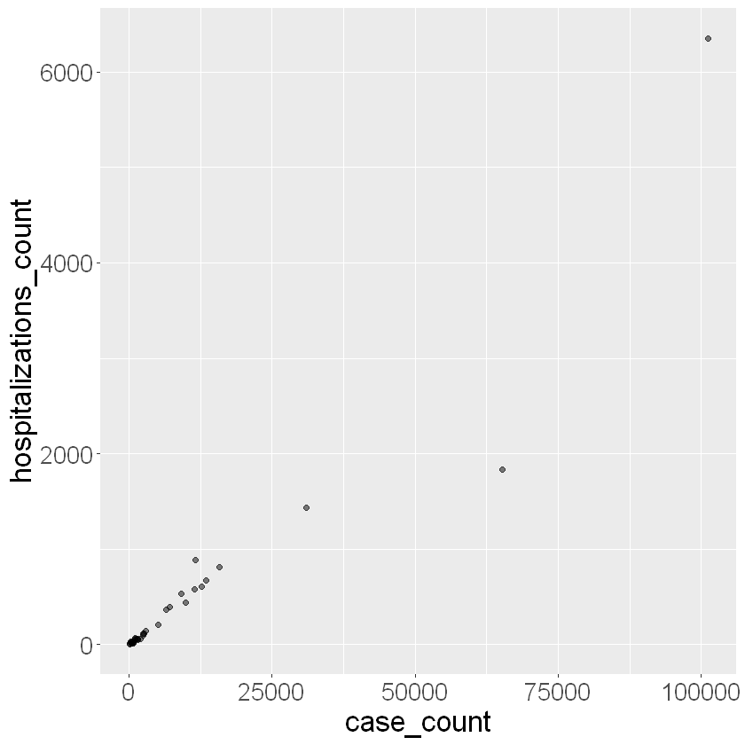

```r
# Adjust our plot window size according to the expected output
options(repr.plot.width=7, repr.plot.height=7)

# scatter plot of case_count vs hospitalizations_count
phu_information.df %>%
slice(2:n()) %>%

# 1. Data
ggplot() +
    # 2. Aesthetics
    aes(x=case_count, y = hospitalizations_count) +
    theme(text = element_text(size = 20)) + # set text size

    # 4. Geoms
    geom_point(alpha = 0.5)
```

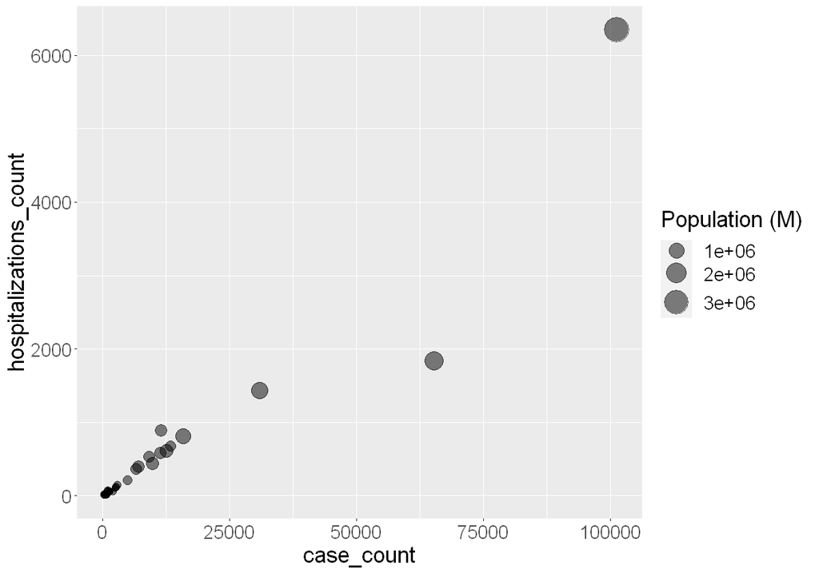

```r
# Adjust our plot window size according to the expected output
options(repr.plot.width=10, repr.plot.height=7)

# bubble plot of case_count vs hospitalizations_count
phu_information.df %>%
slice(2:n()) %>%

# 1. Data
ggplot() +
    # 2. Aesthetics
    aes(x=case_count, y = hospitalizations_count, size = population) +
    theme(text = element_text(size = 20)) + # set text size

    scale_size(range = c(1, 10), name = "Population (M)") + # set the range for sizing our dots

    # 4. Geoms
    geom_point(alpha = 0.5)
```

## 2.2.0 Scale your axes to help see your data better

From above we can see a lot of values are bunched up together at the lower end of our scales and likewise we have a few values that are far out on our x/y axes. To even this out, we can transform our axes to display values on a log10 scale. We have two places where we can accomplish this:

1. Transform your data directly ie `log(case_count)`. Data will be places on a log scale value scale but may have less meaning to the lay person.
2. Transform your scales/tick marks. The data is untouched and the values still have meaning to your audience without having to do conversions in their head.

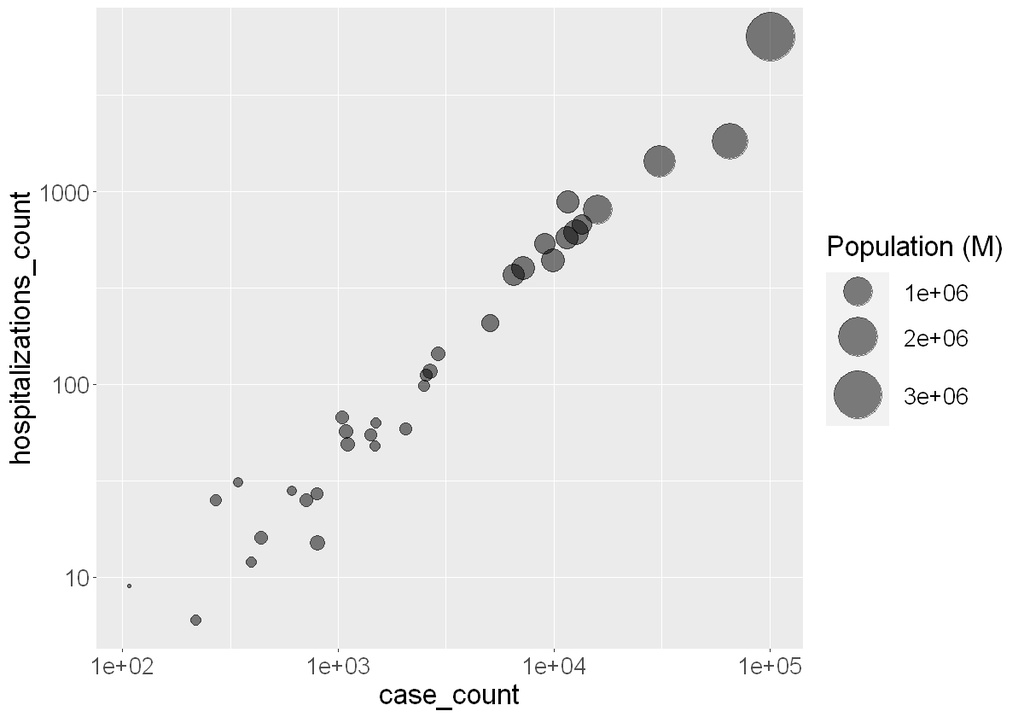

```r
# Adjust our plot window size according to the expected output
options(repr.plot.width=10, repr.plot.height=7)

# bubble plot of case_count vs hospitalizations_count both on a log scale
phu_information.df %>%
slice(2:n()) %>%

# 1. Data
ggplot() +
    # 2. Aesthetics
    aes(x=case_count, y = hospitalizations_count, size = population) +
    theme(text = element_text(size = 20)) + # set text size
    scale_size(range = c(1, 16), name = "Population (M)") + # set the range for sizing our dots

    # 3. Scaling
    scale_x_log10() +
    scale_y_log10() +

    # 4. Geoms
    geom_point(alpha = 0.5)
```

After log-transforming our data it looks like the relationship between overall cases and hospitalization remains linear. We can now, however, see it much easier on our visualization. Intuitively this makes sense as long as the effective reproduction number has averaged closer to 1 in the long-term data.

## 3.0.0 Proportion visualizations display frequency and spread across groups or intervals

Many students are familar with the classic bar chart. Thus far, we've already used it to some extent to look at our last lecture's PHU case data. When comparing groups or populations for differences in their distribution, however, the bar chart falls quite short of the ideal.

When comparing distributions, we again are often concerned with summary statistics - mean, median, standard deviation, confidence intervals. The nature of our data, however, is often not continuous across an entire y-axis interval as a bar chart may suggest but rather our population is the result of values centred, with some variance, around a mean value.

Over the remainder of the lecture we will compare and contrast 4 types of distribution plots for their relevance and when they may be most useful to visualize our data. When applicable to our data visualizations, we will also display all of our data points to better illustrate our distribution versus the visualization. We will examine:

1. Bar charts or Barplots
2. Density plots
3. Box and Whisker plots
4. Violin plots

## 3.1.0 The barplot uses the `geom_bar()` or `geom_col()` to display data

As we have already seen, the `geom_bar()` layer can be used to display our data in multiple ways. The height of the bar is proportional to either the number of observations of each group, or by applying a weight aesthetic to produce the sum of the weights. In our previous examples we actually used the value of our observations to determine height and proportions of our groups by setting the parameter `stat="identity"`. A simpler way to accomplish this is with `geom_col()`, which already uses `stat_identity()` by default to calculate proportions.

| geom | Description | Requirements |
| --- | --- | --- |
| geom_bar() | Counts observations in your data and determines height and proportion | Only accepts x OR y parameter in `aes()` |
| geom_col() | Uses values supplied for the y-axis parameter. | Requires both x AND y parameters in `aes()` |

Both of these plots use `position="stack"` by default and proportions of height match observations or sums for multiple values sharing the same x position. Such instances can be displayed independently using `position="dodge"` or `position=dodge2`. This is only helpful, however, when the occurence of x values is lower, otherwise the graph becomes crowded.

Let's begin with a simple barplot of SARS-Cov-2-related deaths accumulated over the course of the pandemic. Using `phu_information.df` as a data source we are only plotting a series of values or to convey the distribution of proportions across categories.

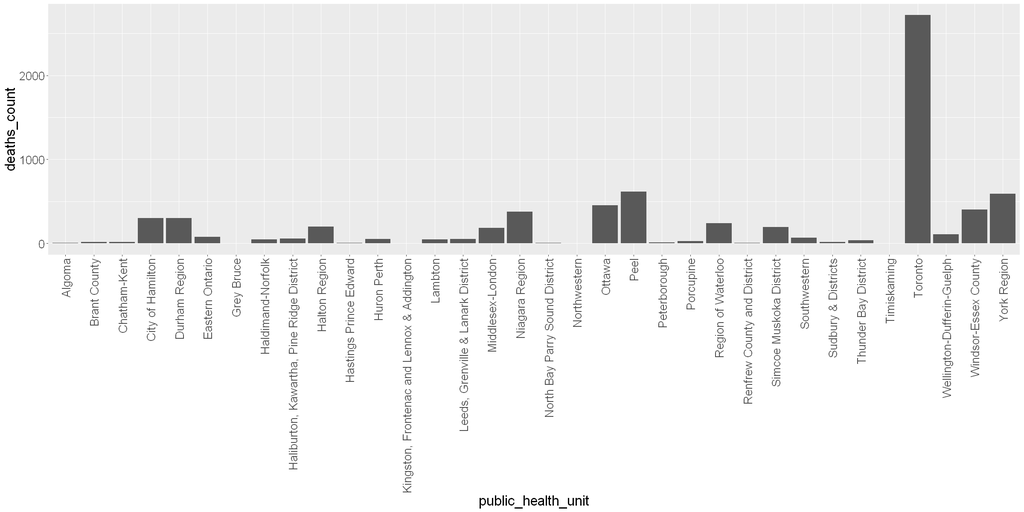

```r
# Adjust our plot window size according to the expected output
options(repr.plot.width=20, repr.plot.height=10)

# barplot of death counts across PHUs
phu_information.df %>%
# Remove the top row (Ontario data)
slice(2:n()) %>%

# 1. Data
ggplot(.) +
    # 2. Aesthetics
    aes(x = public_health_unit, y = deaths_count) +
    theme(text = element_text(size = 20)) + # set text size
    theme(axis.text.x = element_text(angle=90, hjust = 1, vjust=0.5)) + # Adjust our x-axis text

    # 4. Geoms
    geom_col()
```

## 3.1.0 Use `reorder()` to sort your data as you plot it

In the case of phu_information we can do a little better by ordering our x-axis of PHUs by total population or death counts. Since our data table is quite simple and only a single observation for each PHU occurs, there are a number of ways to accomplish a sort:

1. Convert `geographic_area` to a factor and use `fct_reorder()` to sort our factors.
2. Sort the entire table using `arrange()` before plotting.
3. Use the `reorder()` function while generating the plot.

Let's sort our data on the move in our next example.

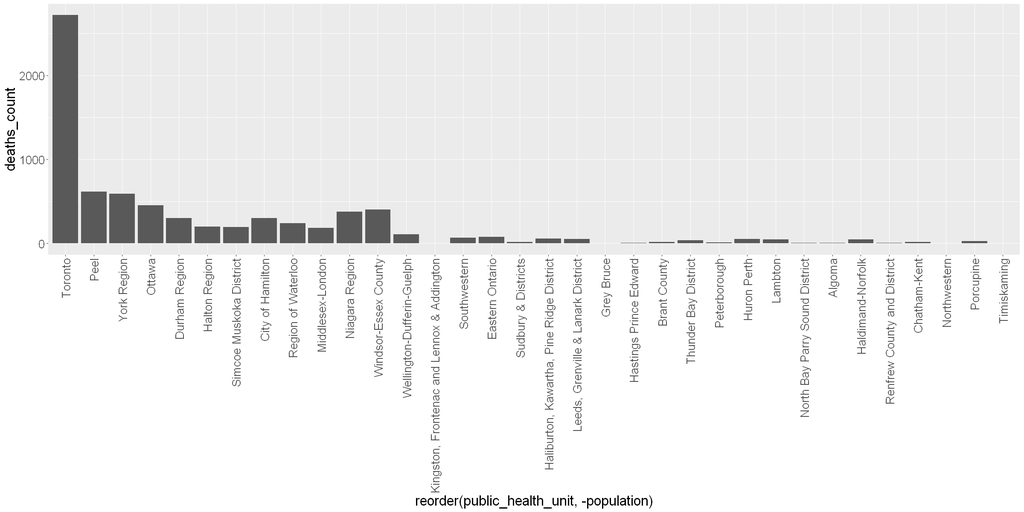

```r
# barplot using the reorder function
phu_information.df %>%
# Remove the top row (Ontario data)
slice(2:n()) %>%
# We must choose a variable to sort by in the reorder function - use population

# 1. Data
ggplot(.) +
    # 2. Aesthetics
    aes(x = reorder(public_health_unit, -population), y = deaths_count) +
    theme(text = element_text(size = 20)) + # set text size
    theme(axis.text.x = element_text(angle=90, hjust = 1, vjust=0.5)) + # Adjust our x-axis text

    # 4. Geoms
    geom_col()
```

## 3.2.0 Barplots can help guide the eye

What are we missing from this visualization that would help the reader It would be nice to know just how much variation there is in population size, especially in the first ~12 PHUs. How much bigger is Peel that the Region of Waterloo?

We can add a little detail by layering an additional geom. In this case, we will use `geom_point()` to add the population of each PHU after scaling it down to 1/1000th.

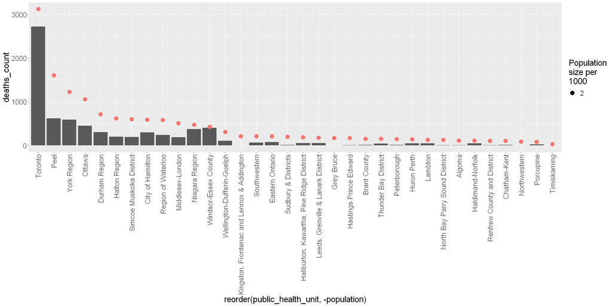

```r
# barplot using the reorder function
phu_information.df %>%
# Remove the top row (Ontario data)
slice(2:n()) %>%
# We must choose a variable to sort by in the reorder function - use population

# 1. Data
ggplot(.) +
    # 2. Aesthetics
    aes(x = reorder(public_health_unit, -population), y = deaths_count) +
    theme(text = element_text(size = 20)) + # set text size
    theme(axis.text.x = element_text(angle=90, hjust = 1, vjust=0.5)) + # Adjust our x-axis text
    guides(size = guide_legend(title="Population\nsize per\n1000"),
           colour = "none") +

    # 4. Geoms
    geom_col() +
    geom_point(aes(y=population/1000, size=2, colour="red"))
```

In contrast, we can plot the exact same data as a bubble plot but is it as effective?

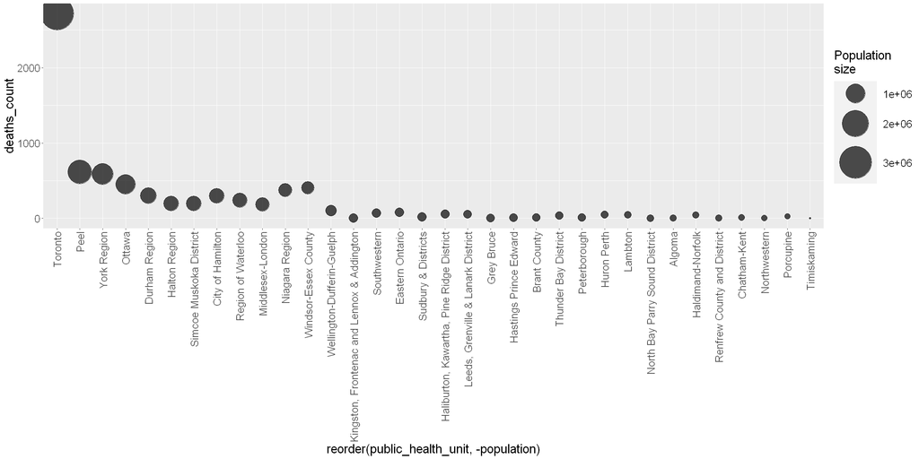

```r
# scatter-style using the reorder function
phu_information.df %>%
# Remove the top row (Ontario data)
slice(2:n()) %>%
# We must choose a variable to sort by in the reorder function - use population
ggplot(.) +
    # 2. Aesthetics
    aes(x = reorder(public_health_unit, -population), y = deaths_count, size=population) +
    theme(text = element_text(size = 20)) + # set text size
    theme(axis.text.x = element_text(angle=90, hjust = 1, vjust=0.5)) + # Adjust our x-axis text
    scale_size(range = c(1, 24), name = "Population (M)") + # set the range for sizing our dots
    guides(size = guide_legend(title="Population\nsize"), colour = "none") +

    # 4. Geoms
    geom_point(alpha = 0.7)
```

## 3.3.0 Barplots to convey proportion or composition

Let's revisit our public health unit data from last week. We'll use an updated long-format version that we created and saved in a csv format. As you might recall this dataset contains a column of dates with each row representing an observation of `new_cases` reported by a `public_health_unit` on that date. We have a 4th column `total_phu_new` representing total cases per reported across all PHUs on that specific date.

| date | public_health_unit | new_cases | total_phu_new |
| --- | --- | --- | --- |
| Date format: YYYY-MM-DD | factor of 34 PHUs | numeric:double | numeric:double |
| ... | ... | ... | ... |

In our first lecture we looked at the other helpful visualization that barplots can produce: composition and proportions. Here we can combine the proportions of categories of data to help convey an added dimension to our data. By stacking PHUs in our "new case" data we are now plotting new cases per month for multiple PHUs. The area of each stack, however, also gives us a sense of proportions for each PHU that we've added.

```r
# Open our data file and define the column types rather than let the function decide.
covid_phu.df <- read_csv("./data/Ontario_daily_change_in_cases_by_phu_long.csv", col_types=("Dfdd"))
#str(covid_phu.df)
```

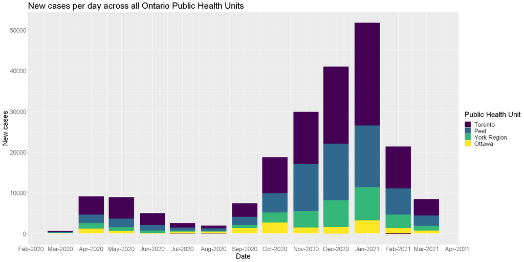

```r
# Adjust our plot window size according to the expected output
options(repr.plot.width=20, repr.plot.height=10)

# Start with our PHU covid data
covid_phu.df %>%
# Filter to just look at a few PHUs
filter(public_health_unit %in% c("Toronto", "Peel", "York Region", "Ottawa")) %>%

# 1. Data
ggplot(.) +
    # 2. Aesthetics
    aes(x = as.Date(as.yearmon(date)), y= new_cases,
        fill = fct_reorder(public_health_unit, new_cases, .desc=TRUE)) + # set our fill colour instead of line colour
    theme(text = element_text(size = 20)) + # set text size

    guides(fill = guide_legend(title="Public Health Unit")) +
    xlab("Date") + # Set the x-axis label
    ylab("New cases") + # Set the y-axis label
    ggtitle("New cases per day across all Ontario Public Health Units") +

    scale_x_date(date_breaks = "1 month", date_labels = "%b-%Y") +
    scale_fill_viridis_d() + # the "d" stands for discrete colour scale

    # 4. Geoms
    geom_col() # Set up our barplot here
```

## 3.4.0 Convert your plots to a circular layout with `coord_polar()`

Generally speaking there are a number of circular or polar coordinate plot variants ranging in complexity from the pie chart to a racetrack chart. The `coord_polar()` layer takes a few parameters:

- `theta`: determines if angles will be mapped to the x or y variable
- `start`: offset from the 12 o'clock position
- `direction`: 1 = clockwise, -1 = counter-clockwise

Here's a summary

| Chart name | Plot description | Uses | Cartesian analog |
| --- | --- | --- | --- |
| Pie chart | Sliced up proportions of a circle | Simple proportion comparison between groups | single bar variant |
| Nightingale/Coxcomb plot | Intervals are equal wedges but shaded areas represent proportions | Intervals with additional categorical proportions | Stacked column plot, theta=x |
| Race track plot | Intervals are split concentrically to form rings of equal width | Helpful if some groups are less diverse | Stack column plot, theta=y |

## 3.4.1 Pie chart work best with simple data

From our pie chart description and from your own experience, you can recall that pie charts aren't helpful with complex data. Once the number of categories surpasses 6-8 things can get hard to visually digest - especially if one category dominates the others.

Let's use the cumulative COVID-19 data from across our PHUs to look at the top 4 PHUs by caseload.

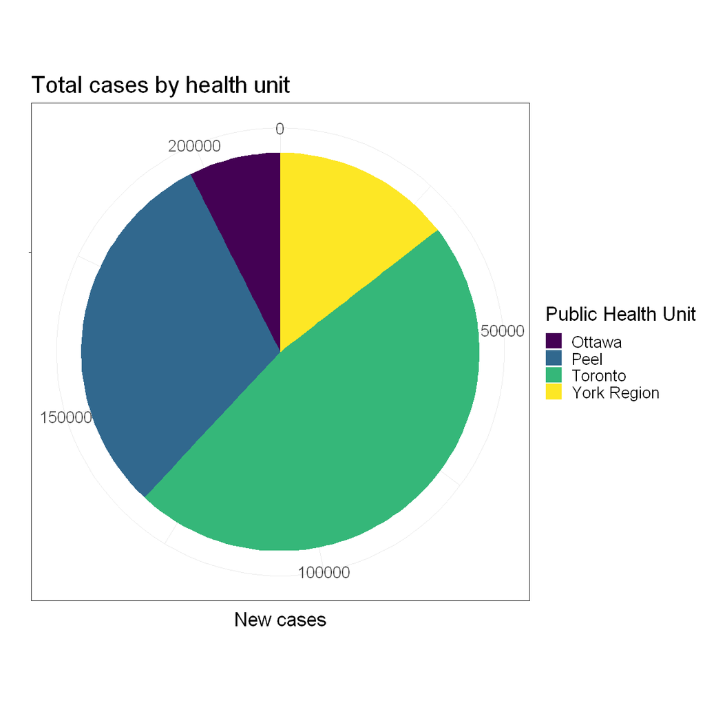

```r
# Adjust our plot window size according to the expected output
options(repr.plot.width=10, repr.plot.height=10)

# Go to the simple phu information table
phu_information.df %>%
# Sort for only a few PHUs
filter(public_health_unit %in% c("Toronto", "Peel", "York Region", "Ottawa")) %>%

# 1. Data
ggplot(.) +
    # 2. Aesthetics
    aes(x="", y=case_count, fill = public_health_unit) + # set our fill colour instead of line colour
    theme_bw()+
    theme(text = element_text(size = 20)) + # set text size
    guides(fill = guide_legend(title="Public Health Unit")) +
    xlab("") + # Set the x-axis label
    ylab("New cases") + # Set the y-axis label
    ggtitle("Total cases by health unit") +

    scale_fill_viridis_d() + # the "d" stands for discrete colour scale

    # 4. Geoms
    geom_bar(width=1, stat="identity") +  # Set up our barplot here

    # 7 Coordinate system
    coord_polar(theta="y")
```

## 3.4.2 Nightingale rose charts emphasize proportions

Made famous by Florence Nightingale, these plots (which she named coxcomb plots) were used to help emphasize the proportions of soldier deaths due to infection during the Crimean war. Each circular increment is equally spaced to represent increasing values along the y-axis. Visually, this gives more area representation as we radiate outwards on the chart. This produces a chart that

1. makes distinguishing larger proportions more obvious.
2. adds a new dimension to the pie chart, allowing us to create intervals for comparison.
3. helps connect our start and end category, especially if they don't represent an ordinal or continuous scale.

**Caution**: outer segments disproportionately represent increases in value. Their larger area produces more visual emphasis despite the linear scale of the y-axis.

We'll switch back to our PHU weekly daily case data to generate some stackable information.

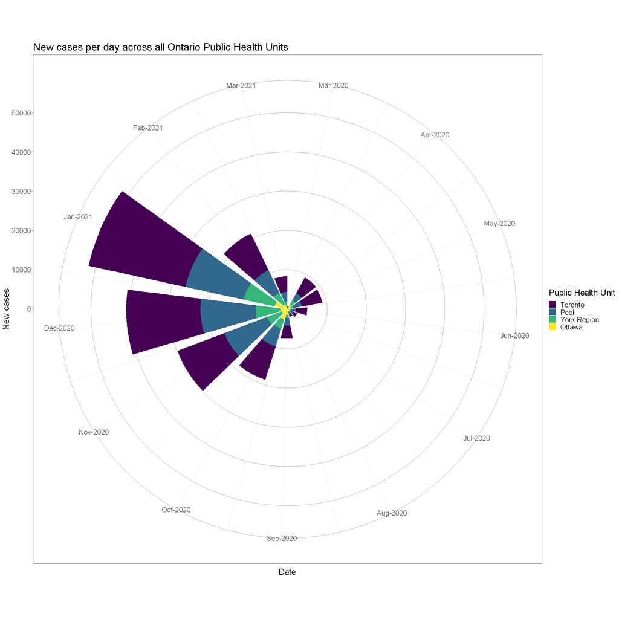

```r
# Adjust our plot window size according to the expected output
options(repr.plot.width=20, repr.plot.height=20)

# Start with our PHU covid data
covid_phu.df %>%
# Filter to just look at a few PHUs
filter(public_health_unit %in% c("Toronto", "Peel", "York Region", "Ottawa")) %>%

# 1. Data
ggplot(.) +
    # 2. Aesthetics
    aes(x = as.Date(as.yearmon(date)), y= new_cases,
        fill = fct_reorder(public_health_unit, new_cases, .desc=TRUE)) + # set our fill colour instead of line colour
    theme_bw() + # make the theme more plain
    theme(text = element_text(size = 20)) + # set text size
    theme(panel.grid.major.y = element_line(color="grey60")) + # darken our major y grid

    guides(fill = guide_legend(title="Public Health Unit")) +
    xlab("Date") + # Set the x-axis label
    ylab("New cases") + # Set the y-axis label
    ggtitle("New cases per day across all Ontario Public Health Units") +

    scale_x_date(date_breaks = "1 month", date_labels = "%b-%Y") + # Scale the dates correctly to get a month-Year format
    scale_fill_viridis_d() + # the "d" stands for discrete colour scale

    # 4. Geoms
    geom_col() + # Set up our barplot here

    # 7 Coordinate system
    coord_polar()
```

## 3.4.3 Racetrack plots are an aesthetic variant of the bar chart

You want to make another cool chart from a boring bar chart. Stacked or otherwise, you can convert those bar plots to a racetrack or radial bar chart. The only difference between the coxcomb plot and radial bar chart is that instead of the default `theta="x"` we set it to `y`. Like flipping the coordinates for a bar chart.

**Caution**: this is an aesthetic transformation where each bar gets relatively longer as you move from inside to out. Therefore values must be judged by radian! Our eyes can more precisely judge differences on a Cartesian bar chart.

Let's make a set of barchart data and compare it to the racetrack plot. Note that negative values in our dataset are plotted separately. It is an implementation quirk of `ggplot`.

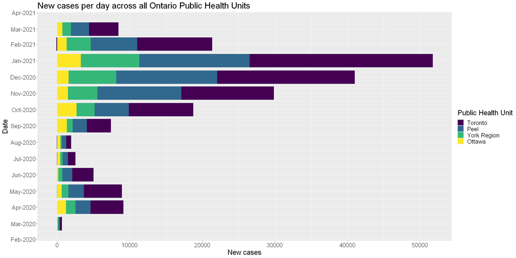

```r
# Adjust our plot window size according to the expected output
options(repr.plot.width=20, repr.plot.height=10)

# Start with our PHU covid data
covid_phu.df %>%
# Filter to just look at a few PHUs
filter(public_health_unit %in% c("Toronto", "Peel", "York Region", "Ottawa")) %>%

# 1. Data
ggplot(.) +
    # 2. Aesthetics
    aes(x = as.Date(as.yearmon(date)), y= new_cases,
        fill = fct_reorder(public_health_unit, new_cases, .desc=TRUE)) + # set our fill colour instead of line colour
    theme(text = element_text(size = 20)) + # set text size

    guides(fill = guide_legend(title="Public Health Unit")) +
    xlab("Date") + # Set the x-axis label
    ylab("New cases") + # Set the y-axis label
    ggtitle("New cases per day across all Ontario Public Health Units") +

    scale_x_date(date_breaks = "1 month", date_labels = "%b-%Y") +
    scale_fill_viridis_d() + # the "d" stands for discrete colour scale

    # 3. Scaling
    coord_flip() + # Flip the x and y axes

    # 4. Geoms
    geom_col() # Set up our barplot here
```

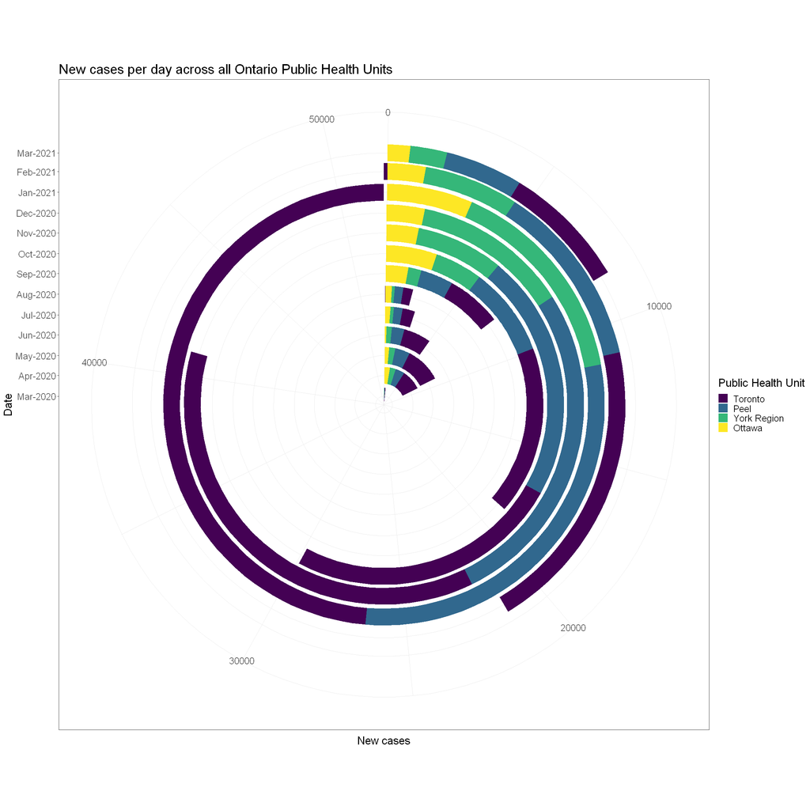

```r
# Adjust our plot window size according to the expected output
options(repr.plot.width=20, repr.plot.height=20)

# Start with our PHU covid data
covid_phu.df %>%
# Filter to just look at a few PHUs
filter(public_health_unit %in% c("Toronto", "Peel", "York Region", "Ottawa")) %>%

# 1. Data
ggplot(.) +
    # 2. Aesthetics
    aes(x = as.Date(as.yearmon(date)), y= new_cases,
        fill = fct_reorder(public_health_unit, new_cases, .desc=TRUE)) + # set our fill colour instead of line colour
    theme_bw() + # make the theme more plain
    theme(text = element_text(size = 20)) + # set text size
    theme(panel.grid.major.y = element_line(color="grey60")) + # darken our major y grid

    guides(fill = guide_legend(title="Public Health Unit")) +
    xlab("Date") + # Set the x-axis label
    ylab("New cases") + # Set the y-axis label
    ggtitle("New cases per day across all Ontario Public Health Units") +

    scale_x_date(date_breaks = "1 month", date_labels = "%b-%Y") + # Scale the dates correctly to get a month-Year format
    scale_fill_viridis_d() + # the "d" stands for discrete colour scale

    # 4. Geoms
    geom_col() + # Set up our barplot here

    # 7 Coordinate system
    coord_polar(theta="y")
```

## 3.4.4 Barplots and their variant summarize the distribution of data between groups or intervals but NOT within single populations.

Often for our purposes as scientists we are more concerned with the distribution of replicates or measurements as a population *within* a group whilst also comparing across other groups (ie control vs treatment). Naively, we are tempted by the convenience of Excel to simplify our data as a bar chart with some simple standard deviation or error bars. One word concisely describes this behaviour:

### Inappropriate.

Note from our examples that although we are comparing public health units, our datapoints represent single observations separated either by group or by time. At each x-axis point we are not comparing the distribution of information in a meaningful way. In fact, from our first example, we can convey a *near-exact* message using a dot-plot! In essence these visualizations are communicating the distribution of samples across multiple categories. More or less, this is about visualizing *proportions*.

## 4.0.0 Density plots compute a theoretical distribution

What is the shape of our data? When we encounter experimental populations and begin sampling or measure for specific characteristics, we inevitably begin to reveal whether or not that characteristic has a predictable range, median value, etc. Density plots, once given enough sample values, begin to predict the shape or distribution of that sampling. We sometimes use this to represent the natural distribution of our original populations.

## 4.0.1 Distribution plots need appropriate data

In contrast to our previous datasets, we are interested in dissecting group characterstics after sampling multiple times. Therefore, before continuing on our journey, we need to find some data that is better considered as population data. Let's open up some more SARS-CoV-2 data from Ontario PHUs that has been broken into age and sex demographics. Before we can do any visualization we'll want to tidy up the data in the following steps:

1. Import the data with `read_csv()`
2. Fix the column names to remove spaces and replace them with "_"
3. Pare down on the columns we want to look at. In this case we'll be focusing only on three indicators: total cases, deaths, and hospitalizations regardless of sex.
4. Summarize the data into proportion of cases for each age group, based on the specific total for each indicator within each PHU.

After all of our transformations, we'll have specific portions of infections, deaths, and hospitalizations within each PHU for each age group.

```r
covid_demographics.df <- read_csv("./data/Ontario_age_sex_COVID-19.csv")
str(covid_demographics.df)
tail(covid_demographics.df)
```

```
tibble [770 x 29] (S3: spec_tbl_df/tbl_df/tbl/data.frame)
 $ Period                                 : chr [1:770] "recent COVID-19 cases" "recent COVID-19 cases" "recent COVID-19 cases" "recent COVID-19 cases" ...
 $ From date                              : chr [1:770] "March 5, 2021" "March 5, 2021" "March 5, 2021" "March 5, 2021" ...
 $ To date                                : chr [1:770] "March 19, 2021" "March 19, 2021" "March 19, 2021" "March 19, 2021" ...
 $ Geographic area                        : chr [1:770] "Ontario" "Ontario" "Ontario" "Ontario" ...
 $ Age group                              : chr [1:770] "0 to 09" "10 to 19" "20 to 29" "30 to 39" ...
 $ Male Cases                             : num [1:770] 717 1072 1959 1486 1209 ...
 $ Male Rate                              : num [1:770] 92 129 182 147 132 ...
 $ Female Cases                           : num [1:770] 671 1014 1725 1374 1277 ...
 $ Female Rate                            : num [1:770] 90.8 128.8 168.3 131.2 133.4 ...
 $ Total Cases                            : num [1:770] 1412 2114 3748 2898 2514 ...
 $ Total Rate                             : num [1:770] 93 131 178 141 134 ...
 $ Male Hospitalizations                  : num [1:770] 3 2 14 23 29 58 67 80 64 15 ...
 $ Male Hospitalizations Rate             : num [1:770] 0.4 0.2 1.3 2.3 3.2 5.7 7.7 14.8 27.9 33.6 ...
 $ Female Hospitalizations                : num [1:770] 3 4 15 26 28 37 48 63 55 27 ...
 $ Female Hospitalizations Rate           : num [1:770] 0.4 0.5 1.5 2.5 2.9 3.6 5.2 10.2 17.7 28.5 ...
 $ Total Hospitalizations Count           : num [1:770] 6 7 29 50 59 95 115 144 121 42 ...
 $ Total Hospitalizations Rate            : num [1:770] 0.4 0.4 1.4 2.4 3.1 4.6 6.4 12.4 22.4 30.1 ...
 $ Male Deaths                            : num [1:770] 0 0 0 0 1 1 0 12 10 2 ...
 $ Male Death Rate                        : num [1:770] 0 0 0 0 0.1 0.1 0 2.2 4.4 4.5 ...
 $ Female Deaths                          : num [1:770] 0 0 0 1 2 3 1 5 11 10 ...
 $ Female Death Rate                      : num [1:770] 0 0 0 0.1 0.2 0.3 0.1 0.8 3.5 10.5 ...
 $ Total Deaths                           : num [1:770] 0 0 0 1 3 4 1 17 22 12 ...
 $ Total Deaths Rate                      : num [1:770] 0 0 0 0 0.2 0.2 0.1 1.5 4.1 8.6 ...
 $ Unknown Gender Deaths                  : num [1:770] 0 0 0 0 0 0 0 0 1 0 ...
 $ Unknown Gender Hospitalizations        : num [1:770] 0 1 0 1 2 0 0 1 2 0 ...
 $ Unknown Gender Cases                   : num [1:770] 24 28 64 38 28 21 13 5 7 1 ...
 $ Unknown Age and Gender Deaths          : num [1:770] 0 0 0 0 0 0 0 0 0 0 ...
 $ Unknown Age and Gender Hospitalizations: num [1:770] 0 0 0 0 0 0 0 0 0 0 ...
 $ Unknown Age and Gender Cases           : num [1:770] 0 0 0 0 0 0 0 0 0 0 ...
 - attr(*, "spec")=
  .. cols(
  ..   Period = col_character(),
  ..   `From date` = col_character(),
  ..   `To date` = col_character(),
  ..   `Geographic area` = col_character(),
  ..   `Age group` = col_character(),
  ..   `Male Cases` = col_double(),
  ..   `Male Rate` = col_double(),
  ..   `Female Cases` = col_double(),
  ..   `Female Rate` = col_double(),
  ..   `Total Cases` = col_double(),
  ..   `Total Rate` = col_double(),
  ..   `Male Hospitalizations` = col_double(),
  ..   `Male Hospitalizations Rate` = col_double(),
  ..   `Female Hospitalizations` = col_double(),
  ..   `Female Hospitalizations Rate` = col_double(),
  ..   `Total Hospitalizations Count` = col_double(),
  ..   `Total Hospitalizations Rate` = col_double(),
  ..   `Male Deaths` = col_double(),
  ..   `Male Death Rate` = col_double(),
  ..   `Female Deaths` = col_double(),
  ..   `Female Death Rate` = col_double(),
  ..   `Total Deaths` = col_double(),
  ..   `Total Deaths Rate` = col_double(),
  ..   `Unknown Gender Deaths` = col_double(),
  ..   `Unknown Gender Hospitalizations` = col_double(),
  ..   `Unknown Gender Cases` = col_double(),
  ..   `Unknown Age and Gender Deaths` = col_double(),
  ..   `Unknown Age and Gender Hospitalizations` = col_double(),
  ..   `Unknown Age and Gender Cases` = col_double()
  .. )
```

A tibble: 6 × 29

| Period <chr> | From date <chr> | To date <chr> | Geographic area <chr> | Age group <chr> | Male Cases <dbl> | Male Rate <dbl> | Female Cases <dbl> | Female Rate <dbl> | Total Cases <dbl> | ... | Female Deaths <dbl> | Female Death Rate <dbl> | Total Deaths <dbl> | Total Deaths Rate <dbl> | Unknown Gender Deaths <dbl> | Unknown Gender Hospitalizations <dbl> | Unknown Gender Cases <dbl> | Unknown Age and Gender Deaths <dbl> | Unknown Age and Gender Hospitalizations <dbl> | Unknown Age and Gender Cases <dbl> |
| --- | --- | --- | --- | --- | --- | --- | --- | --- | --- | --- | --- | --- | --- | --- | --- | --- | --- | --- | --- | --- |
| Cumulative | January 15, 2020 | March 19, 2021 | Southwestern Public Health | 50 to 59 | 166 | 1107.6 | 193 | 1291.4 | 361 | ... | 0 | 0.0 | 3 | 10.0 | 0 | 0 | 2 | 0 | 0 | 0 |
| Cumulative | January 15, 2020 | March 19, 2021 | Southwestern Public Health | 60 to 69 | 130 | 964.5 | 133 | 956.6 | 264 | ... | 4 | 28.8 | 6 | 21.9 | 0 | 0 | 1 | 0 | 0 | 0 |
| Cumulative | January 15, 2020 | March 19, 2021 | Southwestern Public Health | 70 to 79 | 93 | 1064.4 | 91 | 919.2 | 185 | ... | 8 | 80.8 | 19 | 101.9 | 0 | 0 | 1 | 0 | 0 | 0 |
| Cumulative | January 15, 2020 | March 19, 2021 | Southwestern Public Health | 80 to 89 | 45 | 1192.4 | 71 | 1432.0 | 116 | ... | 8 | 161.4 | 17 | 194.7 | 0 | 0 | 0 | 0 | 0 | 0 |
| Cumulative | January 15, 2020 | March 19, 2021 | Southwestern Public Health | 90+ | 13 | 1846.6 | 59 | 4008.2 | 74 | ... | 15 | 1019.0 | 20 | 919.1 | 1 | 0 | 2 | 0 | 0 | 0 |
| Cumulative | January 15, 2020 | March 19, 2021 | Southwestern Public Health | All ages | 1264 | 1205.6 | 1390 | 1303.3 | 2669 | ... | 36 | 33.8 | 67 | 31.7 | 1 | 0 | 15 | 0 | 0 | 0 |

```r
# Format our dataset to focus on total_cases and total_deaths
covid_demographics_total.df <-
covid_demographics.df %>%
rename_with(str_to_lower) %>% # convert to lowercase
rename_with(str_replace_all, pattern="\\s", replacement="_") %>% # replace spaces with "_"

# clean up PHU names in two steps
mutate(geographic_area = str_replace_all(.$geographic_area,
                                         pattern=c("(^Public\\sHealth\\s)"),
                                         replacement = "")) %>%
mutate(geographic_area = str_replace_all(.$geographic_area,
                                         pattern=c("(\\sPublic[\\s\\w]*)|(\\sHealth[\\s\\w]*)"),
                                         replacement = "")) %>%

# Filter the data for cumulative information
filter(period == "Cumulative",
       geographic_area != "Ontario", # Drop Ontario data
       age_group != "All ages") %>%  # Drop all age data

# Pare down the dataset to just total_cases, total_deaths, and total_hospitalizations
select(from_date, to_date, geographic_area, age_group,
       total_cases, total_deaths, total_hospitalizations_count) %>%
# Convert the age_group into a factor
mutate(age_group = factor(age_group)) %>%
rename(public_health_unit = geographic_area) %>%

# Group the data so you can "summarise" in the next steps
group_by(public_health_unit) %>%
mutate(percent_cases = total_cases/sum(total_cases), # generate percent cases for each age group within a PHU
       percent_deaths = total_deaths/sum(total_deaths), # generate percent deaths for each age group within a PHU
       # generate percent hospitalizations for each age group within a PHU
       percent_hospitalizations = total_hospitalizations_count/sum(total_hospitalizations_count))

# Take a look at the different age demographics
levels(covid_demographics_total.df$age_group)
head(covid_demographics_total.df)
```

1. '0 to 09'

2. '10 to 19'

3. '20 to 29'

4. '30 to 39'

5. '40 to 49'

6. '50 to 59'

7. '60 to 69'

8. '70 to 79'

9. '80 to 89'

10. '90+'

A grouped_df: 6 × 10

| from_date <chr> | to_date <chr> | public_health_unit <chr> | age_group <fct> | total_cases <dbl> | total_deaths <dbl> | total_hospitalizations_count <dbl> | percent_cases <dbl> | percent_deaths <dbl> | percent_hospitalizations <dbl> |
| --- | --- | --- | --- | --- | --- | --- | --- | --- | --- |
| January 15, 2020 | March 19, 2021 | Algoma | 0 to 09 | 0 | 0 | 0 | 0.00000000 | 0.00 | 0.0000000 |
| January 15, 2020 | March 19, 2021 | Algoma | 10 to 19 | 20 | 0 | 0 | 0.09174312 | 0.00 | 0.0000000 |
| January 15, 2020 | March 19, 2021 | Algoma | 20 to 29 | 49 | 1 | 0 | 0.22477064 | 0.25 | 0.0000000 |
| January 15, 2020 | March 19, 2021 | Algoma | 30 to 39 | 36 | 0 | 0 | 0.16513761 | 0.00 | 0.0000000 |
| January 15, 2020 | March 19, 2021 | Algoma | 40 to 49 | 36 | 0 | 1 | 0.16513761 | 0.00 | 0.1666667 |
| January 15, 2020 | March 19, 2021 | Algoma | 50 to 59 | 27 | 0 | 0 | 0.12385321 | 0.00 | 0.0000000 |

## 4.1.0 Density and histogram plots model distribution of samples or individuals within a population

Density plots can be thought of as smoothed versions of histograms which have been binned in small intervals. Density plots of a single dimension require a minimum of 4 samples but justifying a KDE on a sample size that small is hard. Histograms are recommended to have at least 30 observations to be considered useful and I would apply this rule of thumb to KDEs as well.

Let's pick a few age groups to plot based on `percent_cases`. We'll use data gathered from each PHU to see if the same general trends (if any) apply regardless of PHU.

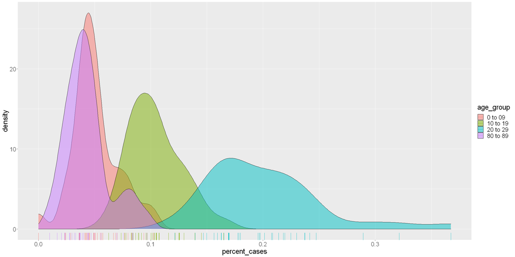

```r
# Adjust our plot window size according to the expected output
options(repr.plot.width=20, repr.plot.height=10)

covid_demographics_total.df %>%
# Filter for just a few age groups
filter(age_group %in% c("0 to 09","10 to 19", "20 to 29", "80 to 89")) %>%

# 1. Data
ggplot(.) +
    # 2. Aesthetics
    aes(x = percent_cases, fill = age_group) +
    theme(text = element_text(size = 20)) + # set text size

    # 4. Geoms
    geom_density(alpha = 0.5) + # generate our KDE
    geom_rug(aes(colour = age_group)) # confirm our data values with a geom_rug
```

## 4.1.1 Apply a `facet_wrap()` to view more KDEs

As you can see from above, as we start to have more and more age groups, it may be better to separate them out in order to avoid too much overlap.

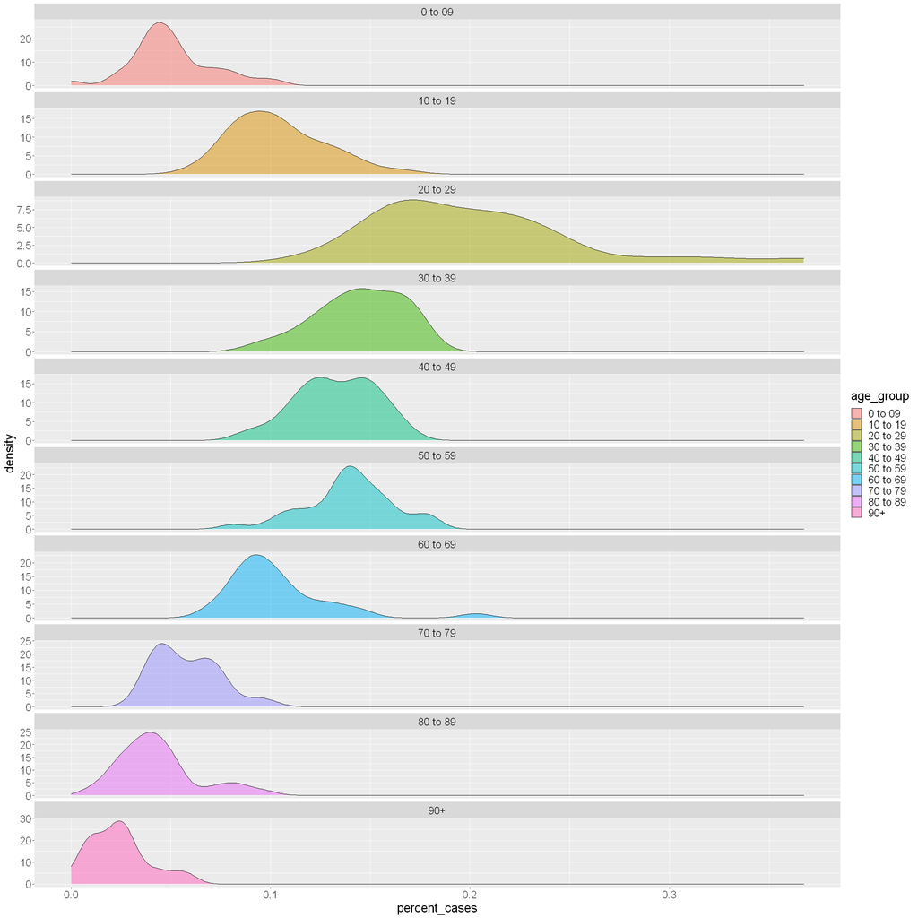

```r
# Adjust our plot window size according to the expected output
options(repr.plot.width=20, repr.plot.height=20)

covid_demographics_total.df %>%
# Select for just the important columns
select(public_health_unit, age_group, percent_cases, percent_deaths) %>%

# 1. Data
ggplot(.) +
    # 2. Aesthetics
    aes(x = percent_cases, fill = age_group) +
    theme(text = element_text(size = 20)) + # set text size

    # 4. Geoms
    geom_density(alpha = 0.5) +

    # 6. Facet
    facet_wrap(~age_group, scales="free_y", ncol=1)
```

## 4.2.0 Plot multiple distributions with a ridgeline plot

Ridgeline plots (sometimes called Joyplots) can generate a compact way to show multiple distributions of numeric values across several groups. The distributions can be shown as either histograms or density plots with all of them aligned to the same horizontal axis. The vertical axis is compressed slightly to generate an overlap between categories.

To generate these visualizations we can use the `ggridges` package which is an extension of `ggplot2`. In this case, that means it uses the same grammar and can be added as a layer call to `geom_density_ridges()`. A parameter to keep in mind:

- `scale`: sets the vertical distance between ridgelines
  - 1: the tallest density curve just touches the baseline of the next vertical category
  - Above 1: increasing overlap
  - Below 1: increasing separation

Let's begin by replicating our facet plot from above.

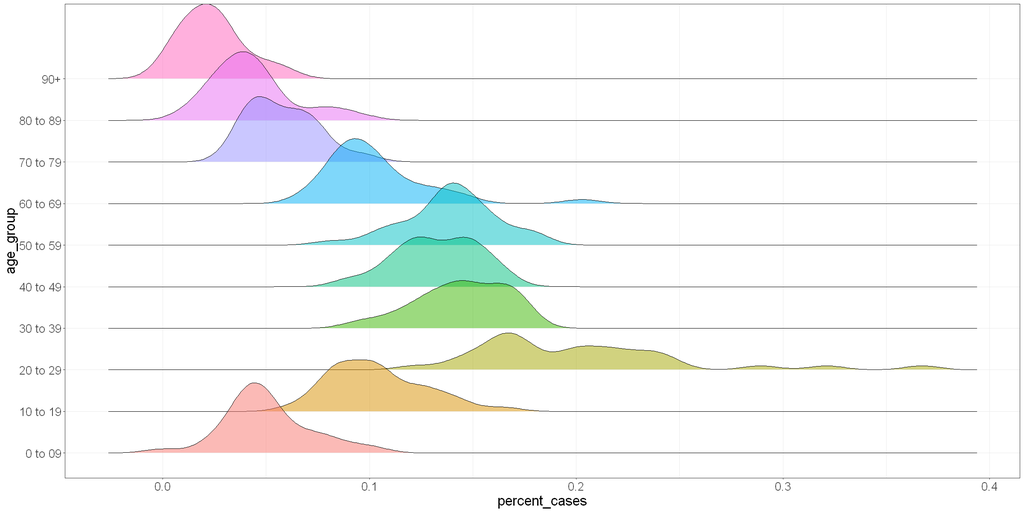

```r
# Adjust our plot window size according to the expected output
options(repr.plot.width=20, repr.plot.height=10)

covid_demographics_total.df %>%
# Select for just the important columns
select(public_health_unit, age_group, percent_cases, percent_deaths) %>%

# Plot a ridgeline plot
# 1. Data
ggplot(.) +
    # 2. Aesthetics
    aes(x = percent_cases, y = age_group, fill = age_group) +
    theme_bw() + # Simplify the underlying theme
    theme(text = element_text(size = 20)) + # set text size
    theme(legend.position = "none") + # drop the legend since it's redundant

    # 4. Geoms
    geom_density_ridges(alpha = 0.5)
```

## 4.3.0 Use `geom_density_ridges_gradient()` to fill densities on a gradient

An additional option with your ridgeline plots is the fill variant. To accomplish a nicer gradient we will include a call to `scale_fill_viridis_c` since our x-axis is continuous. Keep in mind that we also cannot set the `alpha` transparency on our density plots when filling with a gradient. We also have to set our aesthetics `fill` to `stat(x)` to accomplish this feat as well.

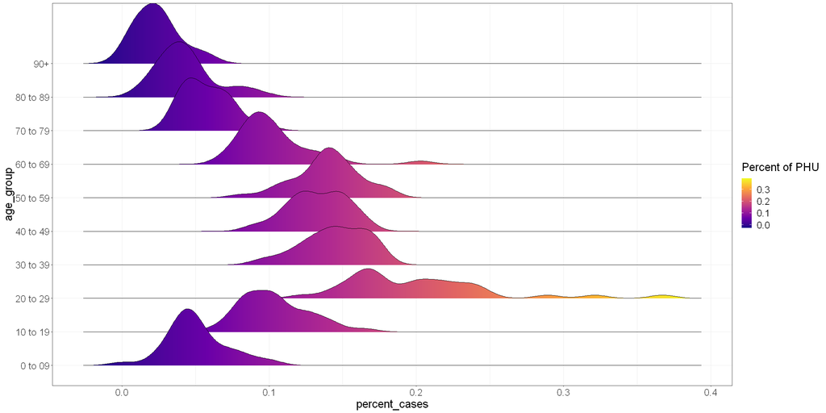

```r
# Adjust our plot window size according to the expected output
options(repr.plot.width=20, repr.plot.height=10)

covid_demographics_total.df %>%
# Select for just the important columns
select(public_health_unit, age_group, percent_cases, percent_deaths) %>%

# Plot a ridgeline plot
# 1. Data
ggplot(.) +
    # 2. Aesthetics
    aes(x = percent_cases, y = age_group, fill = stat(x)) +
    theme_bw() + # Simplify the underlying theme
    theme(text = element_text(size = 20)) + # set text size
    #theme(legend.position = "none") + # drop the legend since it's redundant
    scale_fill_viridis_c(name="Percent of PHU", option = "C") + # Use the Magma option

    # 4. Geoms
    geom_density_ridges_gradient()
```

## 5.0.0 The Boxplot is 50 years young!

First invented in the 1970s by our favourite statistician, John Wilder Tukey, we'll dig into how and when to use this iconic plot.

## 5.1.0 Summarize population distributions with `geom_boxplot()`

As you can see from above, we can comfortably fit a quite few distributions on a ridgeline plot. From the looks of it, the older age groups appear to make up a smaller portion of cases across all PHUs while the 20-29 age group looks to make up a higher percent of cases.

Can we visualize the data in a more summarized form? Let's look at the box plot.

Also known as the box and whisker plot, this visualization conveys the distribution of samples within a group or population and is built upon 5 principal values:

- "Box"
  - **median**: dark line across centre of box
  - **lower quartile**: lower-bound of box
  - **upper quartile**: upper-bound of box
- "Whiskers"
  - **lower extreme**: length of lower whisker
  - **upper extreme**: length of upper whisker

Together, the lower and upper quartiles produce the interquartile range (IQR). The general implementation of boxplots classify any observations 1.5 IQR above the upper quartile or below the lower quartile as **outliers** of the distribution. The characteristics of outliers can be set as parameters within the `geom_boxplot()` layer. Parameters include `outlier.shape`, `outlier.size`, and `outlier.colour`.

Unlike a histogram, the **minimum** number of values to generate a boxplot is 5. While you could generate a boxplot on fewer numbers, you might not have actual whiskers! This is definitely a great alternative when sample sizes are between 5-30 for each population.

*Historically* this was a simple way to visualize summary statistics of population while being easy to produce by hand. Of course, with the age of computing, the production kernel density estimates have allowed for more diverse visualizations. This plot, however, remains a popular format and thus is more readily understood by general audiences.

Each compact box can take up the same space as a barplot column but it gives much more information about the population. Let's look at a single aspect - `percent_cases`.

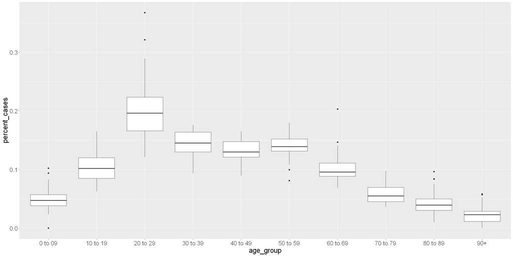

```r
# Adjust our plot window size according to the expected output
options(repr.plot.width=20, repr.plot.height=10)

# Generate a basic box plot with outliers present
covid_demographics_total.df %>%

# 1. Data
ggplot(.) +
    # 2. Aesthetics
    aes(x=age_group, y = percent_cases) +
    theme(text = element_text(size = 20)) + # set text size

    # 4. Geoms
    geom_boxplot() # Add the boxplot geom
```

## 5.2.0 Upgrade your boxplot with some confidence intervals and values

From the looks of it, we can confirm what we saw before in our density plot - that the 20-29 age group generates the highest percentage of cases across PHUs and that with increasing age, the number of reported cases decreases as a proportion of the total.

We can add a few extra items to the plot to help us visualize the data:

- add our data points with `geom_jitter()` and remove outliers from the boxplot to avoid double-plotting points.
- mark a ~95% confidence interval within the shape of each box plot with the `notch` parameter.
- you can set a variable width for each boxplot that is based on the number of samples used to generate the plot.

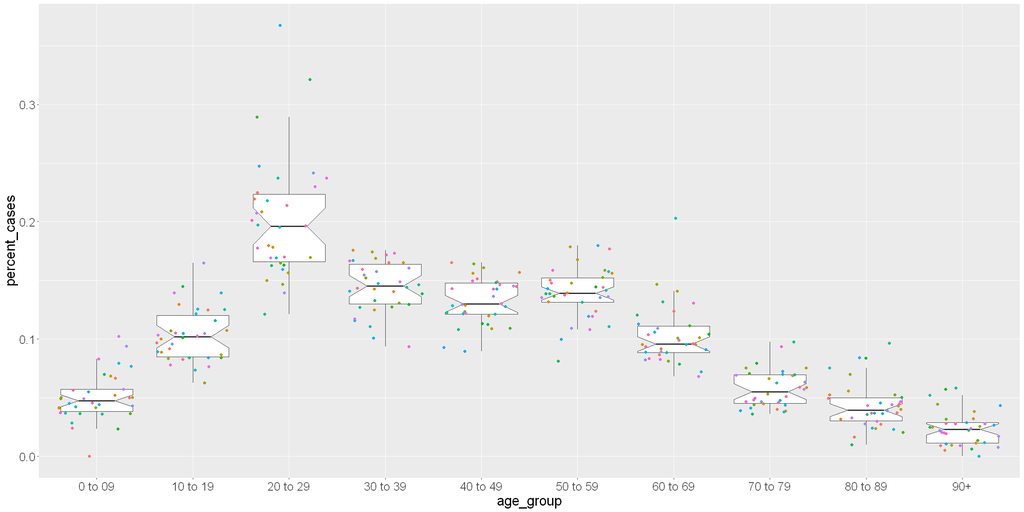

```r
# Adjust our plot window size according to the expected output
options(repr.plot.width=20, repr.plot.height=10)

# Generate a basic box plot with outliers present
covid_demographics_total.df %>%

# 1. Data
ggplot(.) +
    # 2. Aesthetics
    aes(x=age_group, y = percent_cases) +
    theme(text = element_text(size = 20)) + # set text size
    theme(legend.position = "none") +

    # 4. Geoms
    geom_boxplot(outlier.shape=NA, notch=TRUE) + # Add the boxplot geom
    geom_jitter(aes(color = public_health_unit))
```

## 5.3.0 Add a third dimension to your box plot with `fill`

Is there more to the data we've visualized? We can add a third dimension in a number of ways but the simplest would be to compare the proportions of total cases vs totals deaths over the course of this pandemic. To do so, we can pivot our dataset to collapse `percent_cases` and `percent_deaths` together into a single set of variables.

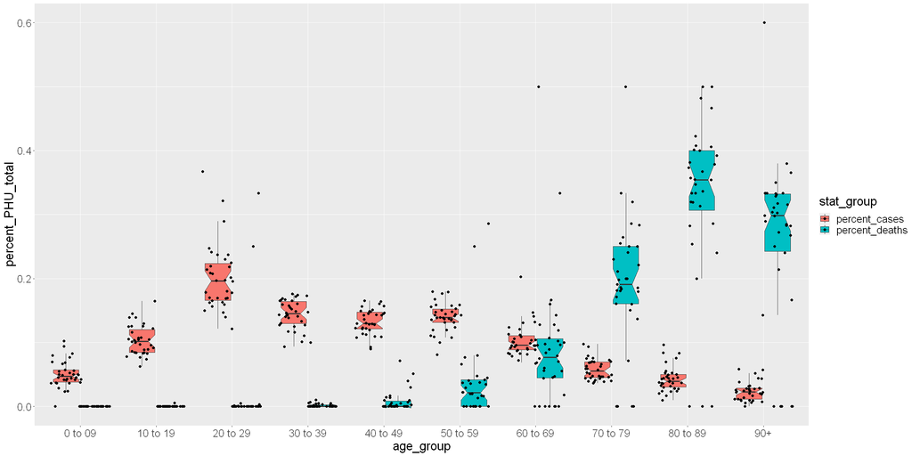

```r
# Adjust our plot window size according to the expected output
options(repr.plot.width=20, repr.plot.height=10)

covid_demographics_total.df %>%
# Select for just the important columns
select(public_health_unit, age_group, percent_cases, percent_deaths) %>%
# Pivot the modified table to capture the "stat_group" of percent_cases vs percent_deaths
pivot_longer(cols=c(3:4), names_to = "stat_group", values_to = "percent_PHU_total") %>%

# Plot the data as a grouped boxplot

# 1. Data
ggplot(.) +
    # 2. Aesthetics
    aes(x=age_group, y = percent_PHU_total, fill = stat_group) +
    theme(text = element_text(size = 20)) + # set text size

    # 3. Scaling
    scale_y_continuous(limits = c(0, 0.6)) + # Set the y-axis limit

    # 4. Geoms
    geom_boxplot(outlier.shape=NA, notch = TRUE) + # Add the boxplot geom
    geom_point(position=position_jitterdodge()) # Add data points for comparison
```

In our boxplots, we are plotting the data in both a boxplot and dotplot format. The shape of the dots helped to give a better sense of PHU distribution within each age group. You can see that the data points overlay on the box but also fall outside. Can we get the compact nature of the boxplot while still getting the visual appeal generated by a density plot?

## 5.4.0 Violin plot - the lovechild of density and boxplots

As the title says, the violin plot is a mixture of both the boxplot and kernel density plot. It's a miniaturized KDE that is mirrored across its axis. It encompasses the summary information of the boxplot but in a pear or violin-shaped distribution. To generate a `geom_violin()` in `ggplot`, a minimum of three values are required. To justify using a violin, I would again suggest sticking to a similar rule of thumb of a minimum ~30 samples/observations to ensure an accurate representation of the distribution.

The nuanced visualization of a violin plot gives much more information than the box plot itself and most boxplots can be replaced with a violin plot. Despite the gateway to more detailed distribution information, this format remains less popular/familiar to scientists. Therefore its immediate accessibility to your audience can be limited.

An important parameter of this geom is:

- `scale`: this sets how big each violin is in comparison to each other.
  - `area`: default value so all violins will have the same area.
  - `count`: scale areas proportionately to observations.
  - `width`: all violins have the same maximum width. Total area is not the same for each.

**Caveats**: much like a KDE, the theoretical distribution could generate some impossible values - especially at the tails. Remember that this is a theoretical distribution based on the data supplied. Depending on how much variation is in your data, and how many outliers it has, it can really affect the shape of your violin.

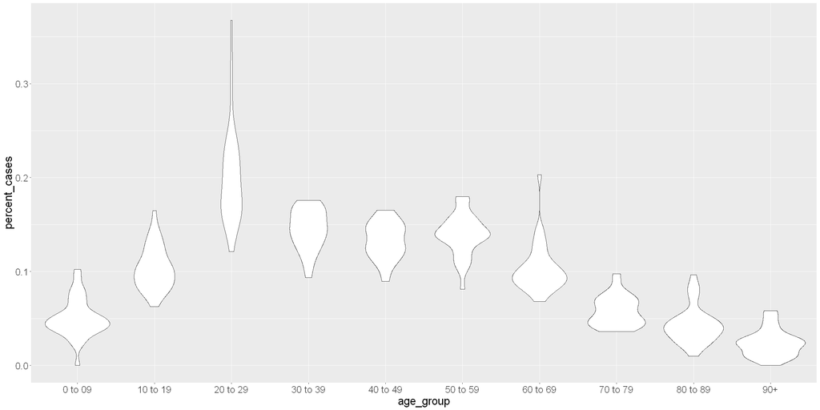

```r
# Adjust our plot window size according to the expected output
options(repr.plot.width=20, repr.plot.height=10)

# Generate a basic box plot with outliers present
covid_demographics_total.df %>%

# 1. Data
ggplot(.) +
    # 2. Aesthetics
    aes(x=age_group, y = percent_cases) +
    theme(text = element_text(size = 20)) + # set text size
    theme(legend.position = "none") +

    # 4. Geoms
    geom_violin() # Add the boxplot geom
    #geom_jitter(aes(colour = public_health_unit))
```

## 5.5.0 Why choose a violin plot over a boxplot?

The major advantage to the violin plot is that, by it's nature, it is very sensitive to the distribution that produces the density estimate. The boxplot represents the summary information of a distribution but is *always* a visual representation of *normal* distribution. There are not enough parameters supplied to represent anything more complex!

The violin plot is not limited in that respect. Despite some of it's visual caveats, it can certainly detect *multi-modal* data. Let's make a toy example to illustrate.

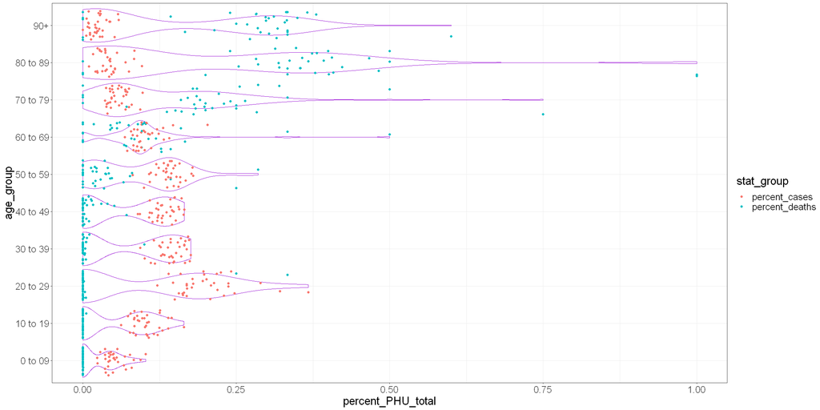

```r
# Adjust our plot window size according to the expected output
options(repr.plot.width=20, repr.plot.height=10)

covid_demographics_total.df %>%
# Select for just the important columns
select(public_health_unit, age_group, percent_cases, percent_deaths) %>%
# Pivot the modified table to capture the "stat_group" of percent_cases vs percent_deaths
pivot_longer(cols=c(3:4), names_to = "stat_group", values_to = "percent_PHU_total") %>%

# Plot a combined violin and boxplot to show difference in distributions

# 1. Data
ggplot(.) +
    # 2. Aesthetics
    aes(x = percent_PHU_total, y = age_group) +
    theme_bw()+
    theme(text = element_text(size = 20)) + # set text size

    # 4. Geoms
    geom_violin(scale = "width", colour="darkviolet") +
    #geom_boxplot(alpha = 0.6) +
    geom_jitter(aes(colour = stat_group))
```

## 5.6.0 Combine violin and boxplots into the ultimate plot

From our above example, you can see that we blended a number of geoms together. With a little working around, we can also plot both violins and boxplots together in a multivariate setting! This gives us the familiarity of the boxplot but also clearly displays the theoretical distribution. Some steps to accomplish this:

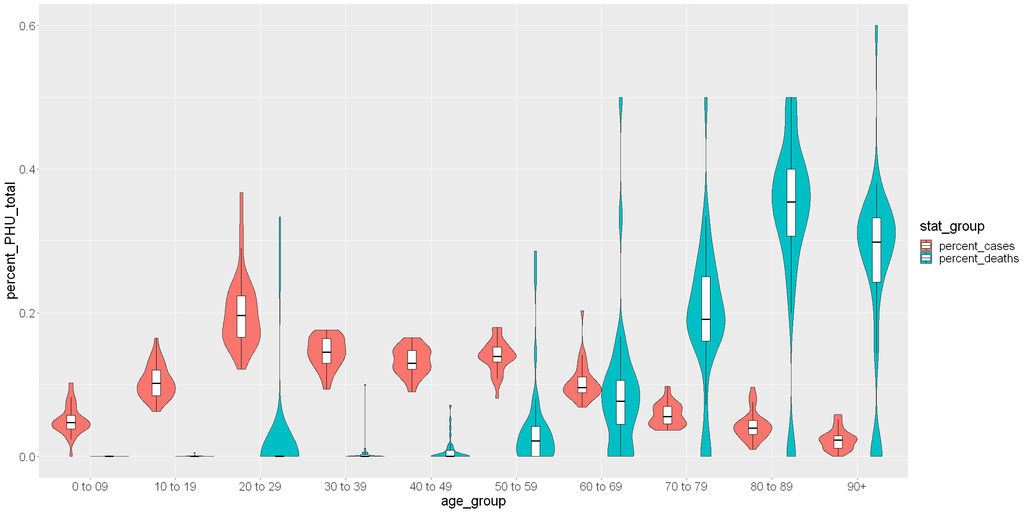

```r
# Adjust our plot window size according to the expected output
options(repr.plot.width=20, repr.plot.height=10)

covid_demographics_total.df %>%
# Select for just the important columns
select(public_health_unit, age_group, percent_cases, percent_deaths) %>%
# Pivot the modified table to capture the "stat_group" of percent_cases vs percent_deaths
pivot_longer(cols=c(3,4), names_to = "stat_group", values_to = "percent_PHU_total") %>%

# Plot the data as a grouped boxplot

# 1. Data
ggplot(.) +
    # 2. Aesthetics
    aes(x=age_group, y = percent_PHU_total) +
    theme(text = element_text(size = 20)) + # set text size
    scale_colour_manual(values=c("black", "black"))+ # we'll need this to fix our boxplots

    # 3. Scaling
    scale_y_continuous(limits = c(0, 0.6)) +

    # 4. Data
    geom_violin(scale="width", aes(fill=stat_group)) + # multi-factor violin plots don't work with area
    geom_boxplot(width=0.2, aes(colour = stat_group), position = position_dodge(width=0.9), outlier.shape=NA)
    #geom_point(position=position_jitterdodge(dodge.width=0.9, jitter.width = 0.3), aes(fill=stat_group, alpha=0.7))
```

## 5.7.0 Parallel coordinate plots can help visualize multivariate date

While the above visualization shows with some clarity the total distribution of our age groups, the messiness of outliers has invaded into the violin plots themselves. An experienced eye, however can still see that the bulk of the population centres around our internal box plots offset the stretched out look of our violins. We could, of course clean it up by removing some of the smaller PHU populations or removing outliers ahead of time.

Suppose, however, we wanted to add a *third* level to our factor like `percent_hospitalizations`? With 10 age groups represented, things would start to get very crowded. To accomodate all of that data, you could facet it into 3 groups based on the statistic used but this would separate the data, which looks sharper when you can see it all on a single plot.

Organizing multiple groups, across multiple categories is the domain of the parallel coordinate plot. The `GGally` package is a `ggplot2` extension with the `ggparcoord` function which allows us to look simultaneously at our 3 indicators (total cases, deaths, and hospitalizations) for each age group, linking each PHU. For each PHU at each indicator, we will draw a line connecting all values across the age groups (coordinates). We will colour our lines based on the category of the indicator.

Although `GGally` is an extension for `ggplot2`, we actually have to wrestle with our data a little bit more and put it back into a wider format. Otherwise we can treat the plot similarly after making it by changing themes etc.

The parameters for `ggparcoord()` require:

- `columns`: a numeric vector of the location of columns that will represent the coordinates (categories/groups/variables).
- `groupColumm`: the column that defines the indicator type (`stat_group`) for the observations.
- `scale`: each coordinate should theoretically have it's own scale but that isn't always possible depending on the data. Instead, the default method of scaling is to normalize points in terms of the standard deviation of the data along that coordinate. You can, however, choose to just use the original scale with `globalminmax` if the ranges of columns aren't too disparate.

To generate this visualization, we'll want to:

1. remake our list of PHUs ordered by descending case load.
2. Pivot our data to wide-format, giving each age group it's own column in our data

```r
# Generate the ordered list of PHUs by total cases
phu_by_cases <- phu_information.df %>%
slice(2:n()) %>% # drop the Ontario data
select(1, 2) %>% # Only take geographic_area and case_count
arrange(desc(case_count)) %>% # sort by descending order
select(1) %>% # grab just the PHU names
unlist() %>% # Unlist
as.character() # Convert to a character vector

# Look at the ordered list of PHUs
phu_by_cases
```

1. 'Toronto'

2. 'Peel'

3. 'York Region'

4. 'Ottawa'

5. 'Windsor-Essex County'

6. 'Durham Region'

7. 'City of Hamilton'

8. 'Region of Waterloo'

9. 'Halton Region'

10. 'Niagara Region'

11. 'Simcoe Muskoka District'

12. 'Middlesex-London'

13. 'Wellington-Dufferin-Guelph'

14. 'Eastern Ontario'

15. 'Southwestern'

16. 'Thunder Bay District'

17. 'Lambton'

18. 'Brant County'

19. 'Haldimand-Norfolk'

20. 'Chatham-Kent'

21. 'Huron Perth'

22. 'Haliburton, Kawartha, Pine Ridge District'

23. 'Sudbury & Districts'

24. 'Leeds, Grenville & Lanark District'

25. 'Kingston, Frontenac and Lennox & Addington'

26. 'Peterborough'

27. 'Grey Bruce'

28. 'Northwestern'

29. 'Hastings Prince Edward'

30. 'Renfrew County and District'

31. 'Porcupine'

32. 'North Bay Parry Sound District'

33. 'Algoma'

34. 'Timiskaming'

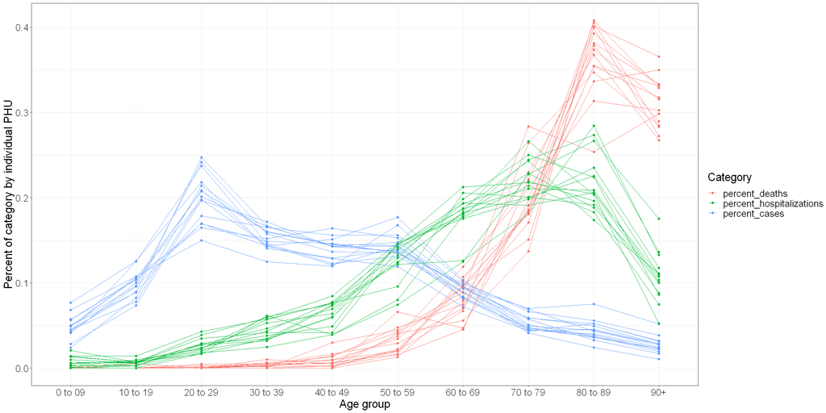

```r
# Adjust our plot window size according to the expected output
options(repr.plot.width=20, repr.plot.height=10)

covid_pcp.df <-

#head(covid_demographics_total.df)
covid_demographics_total.df %>%

# Filter for the top 15 PHUs by case load
filter(public_health_unit %in% phu_by_cases[1:15]) %>%

# Select for just the important columns
select(public_health_unit, age_group, percent_cases, percent_deaths, percent_hospitalizations) %>%

# Pivot the modified table to capture the "stat_group" of percent_cases, percent_deaths, and percent_hospitalizations
pivot_longer(cols=c(3:5), names_to = "stat_group", values_to = "percent_PHU_total") %>%

# We're going to reorder the factor ahead of time
# Probably a better way to do this but requiring more code
mutate(stat_group = factor(stat_group, levels=c("percent_deaths", "percent_hospitalizations", "percent_cases"))) %>%

# Now we're going to pivot out wide to give each age_group ito
pivot_wider(names_from = age_group, values_from = c(percent_PHU_total))

# Generate a ggplot object
# 1. Data and Geoms
ggparcoord(covid_pcp.df, columns=3:12, groupColumn=2,
          showPoints = TRUE, scale="globalminmax") +

    # 2. Aesthetics
    theme_bw() +
    theme(text = element_text(size = 20)) + # set text size
    xlab("Age group") +
    ylab("Percent of category by individual PHU") +
    guides(colour = guide_legend(title="Category"))
```